# Project 1

Tarun Manoharan

2023-09-22

# **1. Background Information**

## *Data set Information*

The ‘Skyscrapers’ data set is data collected by the skyscraper center, on statistics about the tallest buildings in the world, including the materials, status, floors, location, height, start and end year, and the years to build.

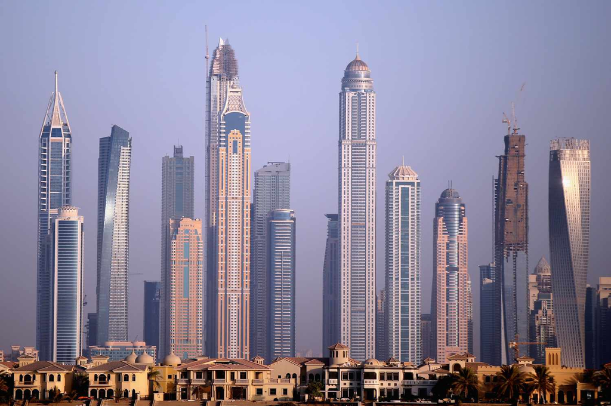

Skyscrapers in Dubai, United Arab Emirates. Francois Nel/Getty Images (cropped)

## *Variable Information*

The chosen variable is the years to build variable, that explains the amount of years the building took to build. The three predictor variables are

- Material, the material used for the building
- Floors, the number of floors the building has
- Height, the height of the building in meters

# **2. Outcome Variable**

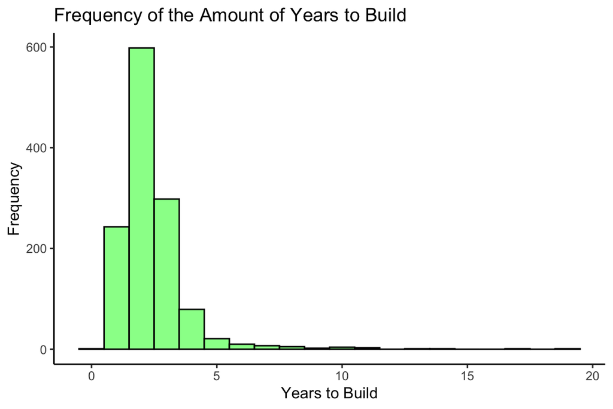

The distribution of this variable is unimodal, and skewed right, the minimum, lower quartile, median, upper quartile, and maximum, are as such, 0, 2, 2, 3, 19, and the mean is 2.4.

# **3. Predictor Variables***

## *Materials*

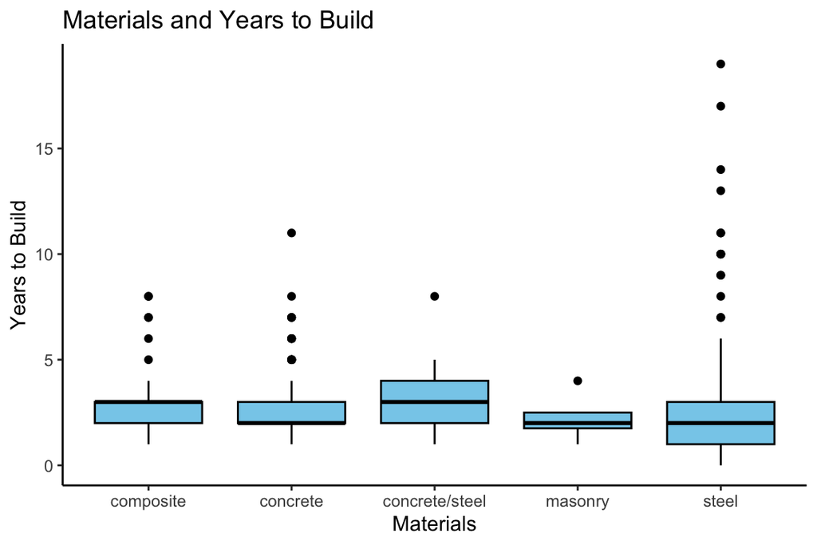

```
        Material YearsToBuild
1      composite         2.96
2       concrete         2.31
3 concrete/steel         2.95
4        masonry         2.25
5          steel         2.40
```

## *Floors*

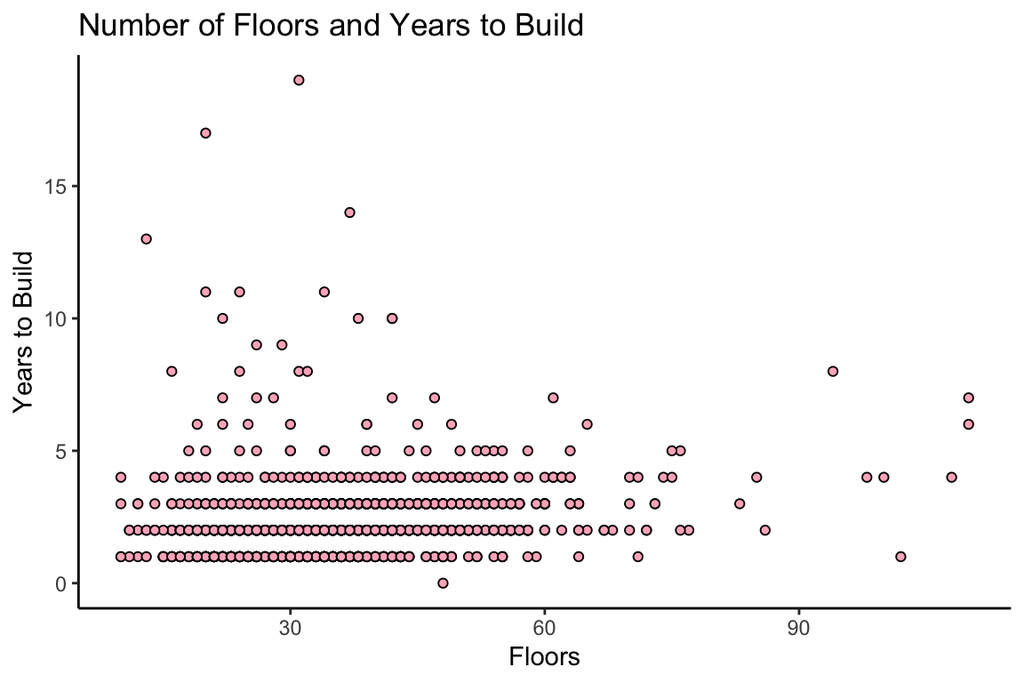

This graph shows the relationship between the number of floors and the years to build, which has a correlation coefficient of 0.15, which means that although positive the relationship between the two is weak, and the number of floors has little to no causation on the years it takes to build.